# Week3_5_Logistic_Regression_adv

###### Logistic Regression: Study on Credit Risk

###### Import Libraries

```python
import pandas as pd
from sklearn.linear_model import LogisticRegression

# importing ploting libraries
import matplotlib.pyplot as plt
# To enable plotting graphs in Jupyter notebook
%matplotlib inline

#importing seaborn for statistical plots
import seaborn as sns

#Let us break the X and y dataframes into training set and test set. For this we will use
#Sklearn package's data splitting function which is based on random function

from sklearn.model_selection import train_test_split

import numpy as np
from scipy import stats

# calculate accuracy measures and confusion matrix
from sklearn import metrics

import warnings
warnings.filterwarnings('ignore')
```

```python
lrdata  = pd.read_csv('/Users/preethamvignesh/Downloads/ML_classwork/Week3strt/CreditRisk.csv')
lrdata.head()
```

|  | Loan_ID | Gender | Married | Dependents | Education | Self_Employed | ApplicantIncome | CoapplicantIncome | LoanAmount | Loan_Amount_Term | Credit_History | Property_Area | Loan_Status |
| --- | --- | --- | --- | --- | --- | --- | --- | --- | --- | --- | --- | --- | --- |
| 0 | LP001002 | Male | No | 0 | Graduate | No | 5849 | 0.0 | 0 | 360.0 | 1.0 | Urban | 1 |
| 1 | LP001003 | Male | Yes | 1 | Graduate | No | 4583 | 1508.0 | 128 | 360.0 | 1.0 | Rural | 0 |
| 2 | LP001005 | Male | Yes | 0 | Graduate | Yes | 3000 | 0.0 | 66 | 360.0 | 1.0 | Urban | 1 |
| 3 | LP001006 | Male | Yes | 0 | Not Graduate | No | 2583 | 2358.0 | 120 | 360.0 | 1.0 | Urban | 1 |
| 4 | LP001008 | Male | No | 0 | Graduate | No | 6000 | 0.0 | 141 | 360.0 | 1.0 | Urban | 1 |

```python
lrdata.shape
```

```
(614, 13)
```

```python
lrdata.info()
```

```
<class 'pandas.core.frame.DataFrame'>
RangeIndex: 614 entries, 0 to 613
Data columns (total 13 columns):
 #   Column             Non-Null Count  Dtype
---  ------             --------------  -----
 0   Loan_ID            614 non-null    object
 1   Gender             601 non-null    object
 2   Married            611 non-null    object
 3   Dependents         599 non-null    object
 4   Education          614 non-null    object
 5   Self_Employed      582 non-null    object
 6   ApplicantIncome    614 non-null    int64
 7   CoapplicantIncome  614 non-null    float64
 8   LoanAmount         614 non-null    int64
 9   Loan_Amount_Term   600 non-null    float64
 10  Credit_History     564 non-null    float64
 11  Property_Area      614 non-null    object
 12  Loan_Status        614 non-null    int64
dtypes: float64(3), int64(3), object(7)
memory usage: 62.5+ KB
```

```python
#Lets analysze the distribution of the various attribute
lrdata.describe().transpose()
```

|  | count | mean | std | min | 25% | 50% | 75% | max |
| --- | --- | --- | --- | --- | --- | --- | --- | --- |
| ApplicantIncome | 614.0 | 5403.459283 | 6109.041673 | 150.0 | 2877.5 | 3812.5 | 5795.00 | 81000.0 |
| CoapplicantIncome | 614.0 | 1621.245798 | 2926.248369 | 0.0 | 0.0 | 1188.5 | 2297.25 | 41667.0 |
| LoanAmount | 614.0 | 141.166124 | 88.340630 | 0.0 | 98.0 | 125.0 | 164.75 | 700.0 |
| Loan_Amount_Term | 600.0 | 342.000000 | 65.120410 | 12.0 | 360.0 | 360.0 | 360.00 | 480.0 |
| Credit_History | 564.0 | 0.842199 | 0.364878 | 0.0 | 1.0 | 1.0 | 1.00 | 1.0 |
| Loan_Status | 614.0 | 0.687296 | 0.463973 | 0.0 | 0.0 | 1.0 | 1.00 | 1.0 |

```python
lrdata.nunique() # Number of unique values in a column
```

```
Loan_ID              614
Gender                 2
Married                2
Dependents             4
Education              2
Self_Employed          2
ApplicantIncome      505
CoapplicantIncome    287
LoanAmount           204
Loan_Amount_Term      10
Credit_History         2
Property_Area          3
Loan_Status            2
dtype: int64
```

**Insights:**

- `Loan_Amount_Term is categorical as it has only 10 unique values`
- `Loan_ID column has all unique values and it not a continous column so it has 614 categories one for each row and that would not provide any info to the algorithm`

```python
lrdata1 = lrdata.drop('Loan_ID', axis =1 ) # dropping this column as it will be 1-1 mapping anyways
lrdata1.head()
```

|  | Gender | Married | Dependents | Education | Self_Employed | ApplicantIncome | CoapplicantIncome | LoanAmount | Loan_Amount_Term | Credit_History | Property_Area | Loan_Status |
| --- | --- | --- | --- | --- | --- | --- | --- | --- | --- | --- | --- | --- |
| 0 | Male | No | 0 | Graduate | No | 5849 | 0.0 | 0 | 360.0 | 1.0 | Urban | 1 |
| 1 | Male | Yes | 1 | Graduate | No | 4583 | 1508.0 | 128 | 360.0 | 1.0 | Rural | 0 |
| 2 | Male | Yes | 0 | Graduate | Yes | 3000 | 0.0 | 66 | 360.0 | 1.0 | Urban | 1 |
| 3 | Male | Yes | 0 | Not Graduate | No | 2583 | 2358.0 | 120 | 360.0 | 1.0 | Urban | 1 |
| 4 | Male | No | 0 | Graduate | No | 6000 | 0.0 | 141 | 360.0 | 1.0 | Urban | 1 |

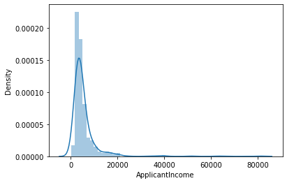

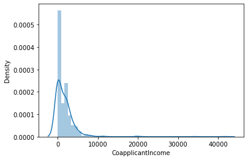

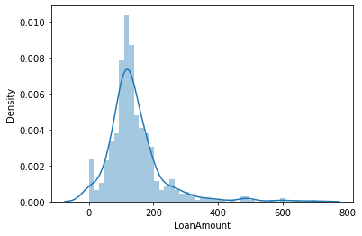

```python
# distplot for continous columns
for i in ['ApplicantIncome','CoapplicantIncome','LoanAmount']:
    sns.distplot(lrdata[i])
    plt.show()
```

```python
lrdata1['Loan_Amount_Term'].value_counts(normalize=True)
```

```
360.0    0.853333
180.0    0.073333
480.0    0.025000
300.0    0.021667
84.0     0.006667
240.0    0.006667
120.0    0.005000
36.0     0.003333
60.0     0.003333
12.0     0.001667
Name: Loan_Amount_Term, dtype: float64
```

**Insights:**

- `Loan_Amount_Term most of the values are 360, and rest categories have a very small percentage. So it won't add much value to create dummies of these columns`

```python
#The Loan_Amount_Term is highly skewed - so we will delete this column
lrdata1.drop(['Loan_Amount_Term'], axis=1, inplace=True)
```

```python
#Convert X & Y variable to a categorical variable wherever relevant
lrdata1['Loan_Status'] = lrdata1['Loan_Status'].astype('category')
lrdata1['Credit_History'] = lrdata1['Credit_History'].astype('category')
```

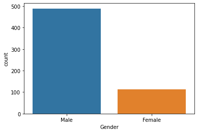

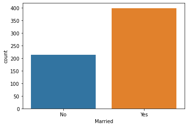

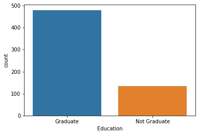

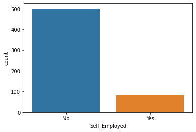

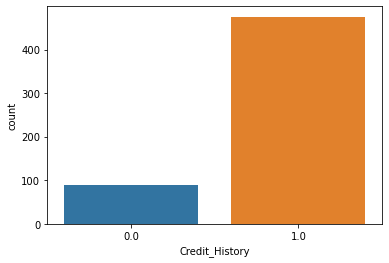

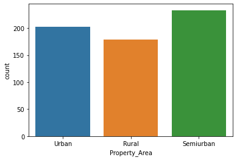

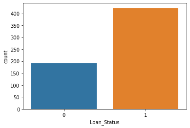

```python
for i in ['Gender','Married','Education','Self_Employed','Credit_History','Property_Area','Loan_Status']:
    sns.countplot(lrdata1[i])
    plt.show()
```

```python
for i in list(lrdata1.columns[lrdata1.dtypes=='object']):   # checking value counts of all object type columns
    print(lrdata1[i].value_counts(normalize=True))
    print()
```

```
Male      0.813644
Female    0.186356
Name: Gender, dtype: float64

Yes    0.651391
No     0.348609
Name: Married, dtype: float64

0     0.575960
1     0.170284
2     0.168614
3+    0.085142
Name: Dependents, dtype: float64

Graduate        0.781759
Not Graduate    0.218241
Name: Education, dtype: float64

No     0.859107
Yes    0.140893
Name: Self_Employed, dtype: float64

Semiurban    0.379479
Urban        0.328990
Rural        0.291531
Name: Property_Area, dtype: float64
```

```python
#Calculate baseline proportion - ratio of Yes to No to identify data imbalance
prop_Y = lrdata1['Loan_Status'].value_counts(normalize=True)
print(prop_Y)
```

```
1    0.687296
0    0.312704
Name: Loan_Status, dtype: float64
```

**Insights:**

- `There is a slight imbalance in the data but no need to treat it`

###### NULL values count

```python
lrdata1.isnull().sum()
```

```
Gender               13
Married               3
Dependents           15
Education             0
Self_Employed        32
ApplicantIncome       0
CoapplicantIncome     0
LoanAmount            0
Credit_History       50
Property_Area         0
Loan_Status           0
dtype: int64
```

###### Filling the NULL values

```python
#filling Null Values

lrdata1['Credit_History'].fillna(0,inplace=True)

lrdata1['Self_Employed'].fillna('No',inplace=True) #replacing with mode

lrdata1['Dependents'].fillna('0',inplace=True) #replacing with mode
```

**Insights:**

- `Credit_History missing values are filled with 0 assuming that they don't meet credit history guidlines .`
- `Self_Employed missing values are replaced with mode, as maximum people are not self employed`
- `Dependents are also filled with mode, assuming most of the people do not have dependents`

```python
# Drawing relationship between CoapplicantIncome and Gender

lrdata1.groupby('Gender')['CoapplicantIncome'].median()
```

```
Gender
Female       0.0
Male      1430.0
Name: CoapplicantIncome, dtype: float64
```

```python
## Filling null values in gender whose CoapplicantIncome is 0 with female

z = lrdata1[lrdata1['CoapplicantIncome']==0]
z['Gender'] = z['Gender'].fillna('Female')

lrdata1.update(z)

# .update() works on index values
# so all the value in lrdata1 will replaced by z values wherever the index value in cr_df are same to z
```

```python
lrdata1['Gender'].fillna('Male',inplace=True) #replacing remaining values with mode as no other relationship found
```

```python
#Drawing relationship between Loan_Status, Gender, Property_Area, Married

lrdata.groupby(['Loan_Status','Gender','Property_Area'])['Married'].value_counts()
```

```
Loan_Status  Gender  Property_Area  Married
0            Female  Rural          No           7
                                    Yes          3
                     Semiurban      No          12
                                    Yes          1
                     Urban          No          10
                                    Yes          4
             Male    Rural          Yes         39
                                    No          18
                     Semiurban      Yes         27
                                    No          12
                     Urban          Yes         35
                                    No          19
1            Female  Rural          No          12
                                    Yes          2
                     Semiurban      No          22
                                    Yes         19
                     Urban          No          17
                                    Yes          2
             Male    Rural          Yes         68
                                    No          26
                     Semiurban      Yes        100
                                    No          32
                     Urban          Yes         88
                                    No          23
Name: Married, dtype: int64
```

```python
lrdata1[lrdata1['Married'].isnull()]
```

|  | Gender | Married | Dependents | Education | Self_Employed | ApplicantIncome | CoapplicantIncome | LoanAmount | Credit_History | Property_Area | Loan_Status |
| --- | --- | --- | --- | --- | --- | --- | --- | --- | --- | --- | --- |
| 104 | Male | NaN | 0 | Graduate | No | 3816.0 | 754.0 | 160.0 | 1.0 | Urban | 1.0 |
| 228 | Male | NaN | 0 | Graduate | No | 4758.0 | 0.0 | 158.0 | 1.0 | Semiurban | 1.0 |
| 435 | Female | NaN | 0 | Graduate | No | 10047.0 | 0.0 | 0.0 | 1.0 | Semiurban | 1.0 |

**Insights:**

- `When Gender is Male Loan Status is 1 and Propert_Area is Urban then mostly they are married.(mode)`

```python
## Replacing with mode observed in above mentioned relationship:

lrdata1.loc[104,'Married'] = 'Yes'
lrdata1.loc[228,'Married'] = 'Yes'
lrdata1.loc[435,'Married'] = 'No'
```

```python
lrdata1.isnull().sum()
```

```
Gender               0
Married              0
Dependents           0
Education            0
Self_Employed        0
ApplicantIncome      0
CoapplicantIncome    0
LoanAmount           0
Credit_History       0
Property_Area        0
Loan_Status          0
dtype: int64
```

###### Bivariate Analysis

**Think about it:**

- In this case-study, we are going to apply Logistic Regression.
- But even before we apply, let's have a look at the data to see how each attribute is different when loan status is yes or not.
- To check it, we ll have to use groupby and crosstabs.

```python
# Let us look at the target column which is 'Loan_Status' to understand how the data is distributed amongst the various values
lrdata1.groupby(["Loan_Status"]).mean()
```

| Loan_Status | ApplicantIncome | CoapplicantIncome | LoanAmount | Credit_History |
| --- | --- | --- | --- | --- |
| 0.0 | 5446.078125 | 1877.807292 | 142.557292 | 0.505208 |
| 1.0 | 5384.068720 | 1504.516398 | 140.533175 | 0.895735 |

```python
lrdata1.groupby(["Loan_Status"]).median()
```

| Loan_Status | ApplicantIncome | CoapplicantIncome | LoanAmount | Credit_History |
| --- | --- | --- | --- | --- |
| 0.0 | 3833.5 | 268.0 | 126.5 | 1.0 |
| 1.0 | 3812.5 | 1239.5 | 125.0 | 1.0 |

**Insights:**

- `No major difference in case of ApplicantIncome and LoanAmount values w.r.t. target variable`
- `But CoapplicantIncome is higher for people who take loan`

```python
# pd.crosstab(lrdata1['Married'],lrdata1['Loan_Status'],normalize='index')
```

```python
pd.crosstab(lrdata1['Self_Employed'],lrdata1['Loan_Status'],normalize='columns')
```

| Loan_Status Self_Employed | 0.0 | 1.0 |
| --- | --- | --- |
| No | 0.864583 | 0.867299 |
| Yes | 0.135417 | 0.132701 |

```python
pd.crosstab(lrdata1['Property_Area'],lrdata1['Loan_Status'],normalize='columns')
```

| Loan_Status Property_Area | 0.0 | 1.0 |
| --- | --- | --- |
| Rural | 0.359375 | 0.260664 |
| Semiurban | 0.281250 | 0.424171 |
| Urban | 0.359375 | 0.315166 |

**Insights:**

- `Semi Urban people are taking more loans`

```python
pd.crosstab(lrdata1['Dependents'],lrdata1['Loan_Status'],normalize='index')
```

| Loan_Status Dependents | 0.0 | 1.0 |
| --- | --- | --- |
| 0 | 0.313889 | 0.686111 |
| 1 | 0.352941 | 0.647059 |
| 2 | 0.247525 | 0.752475 |
| 3+ | 0.352941 | 0.647059 |

###### Logistic Regression

```python
## Define X and Y variables

X = lrdata1.drop('Loan_Status', axis=1)
Y = lrdata1['Loan_Status'].astype('category')

# change data typr to 'category' because it was object type which is not recognized by model
```

```python
#Convert categorical vriables to dummy variables
X = pd.get_dummies(X, drop_first=True)
```

```python
##Split into training and test set
from sklearn.model_selection import train_test_split

X_train, X_test, y_train, y_test = train_test_split(X, Y, test_size=0.30,random_state=7)
```

```python
from sklearn.metrics import confusion_matrix, recall_score, precision_score, f1_score, roc_auc_score,accuracy_score
from sklearn.linear_model import LogisticRegression

logreg = LogisticRegression(random_state=4294967295,fit_intercept=False)
logreg.fit(X_train, y_train)                    # fit the model on train data
```

```
LogisticRegression(fit_intercept=False, random_state=4294967295)
```

```python
y_predict = logreg.predict(X_test)              # Predicting the target variable on test data
```

```python
# Observe the predicted and observed classes in a dataframe.

z = X_test.copy()
z['Observed Loan Status'] = y_test
z['Predicted Loan Status'] = y_predict
z.head()
```

|  | ApplicantIncome | CoapplicantIncome | LoanAmount | Credit_History | Gender_Male | Married_Yes | Dependents_1 | Dependents_2 | Dependents_3+ | Education_Not Graduate | Self_Employed_Yes | Property_Area_Semiurban | Property_Area_Urban | Observed Loan Status | Predicted Loan Status |
| --- | --- | --- | --- | --- | --- | --- | --- | --- | --- | --- | --- | --- | --- | --- | --- |
| 220 | 2221.0 | 0.0 | 60.0 | 0.0 | 1 | 1 | 0 | 0 | 0 | 0 | 0 | 0 | 1 | 0.0 | 0.0 |
| 109 | 2071.0 | 754.0 | 94.0 | 1.0 | 1 | 1 | 0 | 0 | 1 | 1 | 0 | 1 | 0 | 1.0 | 1.0 |
| 569 | 3166.0 | 2064.0 | 104.0 | 0.0 | 1 | 1 | 0 | 0 | 0 | 0 | 0 | 0 | 1 | 0.0 | 0.0 |
| 330 | 4384.0 | 1793.0 | 117.0 | 1.0 | 1 | 0 | 1 | 0 | 0 | 0 | 0 | 0 | 1 | 1.0 | 1.0 |
| 407 | 2213.0 | 0.0 | 66.0 | 1.0 | 0 | 0 | 0 | 0 | 0 | 1 | 0 | 0 | 0 | 1.0 | 1.0 |

```python
## function to get confusion matrix in a proper format
def draw_cm( actual, predicted ):
    cm = confusion_matrix( actual, predicted)
    sns.heatmap(cm, annot=True,  fmt='.2f', xticklabels = [0,1] , yticklabels = [0,1] )
    plt.ylabel('Observed')
    plt.xlabel('Predicted')
    plt.show()
```

```
Trainig accuracy 0.7412587412587412

Testing accuracy 0.7567567567567568

Confusion Matrix
```

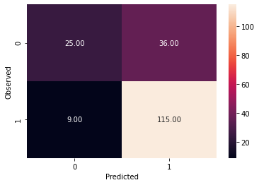

```
None

Recall: 0.9274193548387096

Precision: 0.7615894039735099

F1 Score: 0.8363636363636364

Roc Auc Score: 0.7624272871496562
```

```python
print("Trainig accuracy",logreg.score(X_train,y_train))
print()
print("Testing accuracy",logreg.score(X_test, y_test))
print()
print('Confusion Matrix')
print(draw_cm(y_test,y_predict))
print()
print("Recall:",recall_score(y_test,y_predict))
print()
print("Precision:",precision_score(y_test,y_predict))
print()
print("F1 Score:",f1_score(y_test,y_predict))
print()
print("Roc Auc Score:",roc_auc_score(y_test,logreg.predict_proba(X_test)[:,1] ))
```

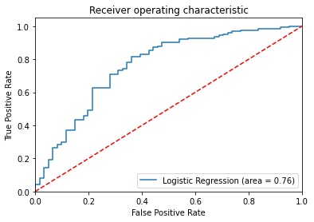

```python
# !pip install yellowbrick

# Additional

#AUC ROC curve
from sklearn.metrics import roc_auc_score
from sklearn.metrics import roc_curve

logit_roc_auc = roc_auc_score(y_test, logreg.predict_proba(X_test)[:,1])
fpr, tpr, thresholds = roc_curve(y_test, logreg.predict_proba(X_test)[:,1])
plt.figure()
plt.plot(fpr, tpr, label='Logistic Regression (area = %0.2f)' % logit_roc_auc)
plt.plot([0, 1], [0, 1],'r--')
plt.xlim([0.0, 1.0])
plt.ylim([0.0, 1.05])
plt.xlabel('False Positive Rate')
plt.ylabel('True Positive Rate')
plt.title('Receiver operating characteristic')
plt.legend(loc="lower right")
plt.savefig('Log_ROC')
plt.show()
```

```python
## Feature Importance or Coefficients
fi = pd.DataFrame()
fi['Col'] = X_train.columns
fi['Coeff'] = np.round(abs(logreg.coef_[0]),2)
fi.sort_values(by='Coeff',ascending=False)
```

|  | Col | Coeff |
| --- | --- | --- |
| 3 | Credit_History | 1.62 |
| 11 | Property_Area_Semiurban | 0.58 |
| 9 | Education_Not Graduate | 0.42 |
| 5 | Married_Yes | 0.26 |
| 4 | Gender_Male | 0.23 |
| 7 | Dependents_2 | 0.23 |
| 6 | Dependents_1 | 0.19 |
| 12 | Property_Area_Urban | 0.09 |
| 8 | Dependents_3+ | 0.07 |
| 10 | Self_Employed_Yes | 0.04 |
| 0 | ApplicantIncome | 0.00 |
| 1 | CoapplicantIncome | 0.00 |
| 2 | LoanAmount | 0.00 |

##### `Important Metric`

Here the bank wants to give loan to the people who are eligible for the home loan i.e. **less number of False Positive**, if FP is high bank would lose money. So that the bank doesn't lose money on the people who are not eligible for the loan. Hence **Precision is the important metric**.

In case of False negative bank will lose few customers but that okay because the bank would want to retain money more than customers who are not eligible for loan.

After achieving the desired accuracy we can deploy the model for practical use. As in the bank now can predict who is eligible for home loan. They can use the model for upcoming customers.